# Problem 4: PCA from Scratch vs. UMAP on Cancer Gene Expression

This notebook implements every part of Problem 4 using the local `gene+expression+cancer+rna+seq.zip` archive. PCA is implemented from scratch in NumPy using both SVD and the Gram-matrix eigendecomposition trick. UMAP uses the `umap-learn` package, as allowed by the prompt.

```python
from pathlib import Path
import io
import tarfile
import zipfile
import warnings

import numpy as np
import pandas as pd
import matplotlib.pyplot as plt

from sklearn.linear_model import LogisticRegression
from sklearn.metrics import accuracy_score
from sklearn.model_selection import train_test_split

plt.style.use("seaborn-v0_8-whitegrid")
RANDOM_STATE = 42
np.random.seed(RANDOM_STATE)
```

## 4(a) Look at the data

```python
def read_gene_expression_archive(zip_path="gene+expression+cancer+rna+seq.zip"):
    """Load data.csv and labels.csv from the UCI zip without manual extraction."""
    zip_path = Path(zip_path)
    extracted_dir = Path("TCGA-PANCAN-HiSeq-801x20531")
    extracted_data = extracted_dir / "data.csv"
    extracted_labels = extracted_dir / "labels.csv"

    if extracted_data.exists() and extracted_labels.exists():
        return pd.read_csv(extracted_data), pd.read_csv(extracted_labels)

    with zipfile.ZipFile(zip_path) as zf:
        tar_name = next(name for name in zf.namelist() if name.endswith(".tar.gz"))
        tar_bytes = io.BytesIO(zf.read(tar_name))

    with tarfile.open(fileobj=tar_bytes, mode="r:gz") as tf:
        members = {member.name: member for member in tf.getmembers()}
        data_name = next(name for name in members if name.endswith("/data.csv"))
        labels_name = next(name for name in members if name.endswith("/labels.csv"))

        with tf.extractfile(members[data_name]) as data_file:
            data = pd.read_csv(data_file)
        with tf.extractfile(members[labels_name]) as labels_file:
            labels = pd.read_csv(labels_file)

    return data, labels


data_raw, labels_raw = read_gene_expression_archive()
print("data.csv shape:", data_raw.shape)
print("labels.csv shape:", labels_raw.shape)
print("data columns, first 5:", list(data_raw.columns[:5]))
print("labels columns:", list(labels_raw.columns))

gene_id_col = data_raw.columns[0]
label_id_col = labels_raw.columns[0]
label_col = labels_raw.columns[1]

X_df = data_raw.drop(columns=[gene_id_col])
y = labels_raw[label_col].astype(str)

print("X shape after dropping ID:", X_df.shape)
print("Class counts:")
display(y.value_counts().sort_index())
```

```
data.csv shape: (801, 20532)
labels.csv shape: (801, 2)
data columns, first 5: ['Unnamed: 0', 'gene_0', 'gene_1', 'gene_2', 'gene_3']
labels columns: ['Unnamed: 0', 'Class']
X shape after dropping ID: (801, 20531)
Class counts:
```

```
Class
BRCA    300
COAD     78
KIRC    146
LUAD    141
PRAD    136
Name: count, dtype: int64
```

```python
assert X_df.shape == (801, 20531), f"Expected (801, 20531), got {X_df.shape}"
assert len(y) == len(X_df), "Labels and data must have the same number of rows."
```

```python
# Full describe is very wide, so also show a reproducible subset of gene columns.
random_gene_cols = X_df.sample(n=8, axis=1, random_state=RANDOM_STATE).columns
print("Summary for a few random gene columns:")
display(X_df[random_gene_cols].describe())

value_min = X_df.to_numpy().min()
value_max = X_df.to_numpy().max()
print(f"Approximate expression-value range in this dataset: {value_min:.3f} to {value_max:.3f}")
```

```
Summary for a few random gene columns:
```

|  | gene_1272 | gene_3222 | gene_6423 | gene_16755 | gene_12457 | gene_6956 | gene_5921 | gene_17784 |
| --- | --- | --- | --- | --- | --- | --- | --- | --- |
| count | 801.000000 | 801.000000 | 801.000000 | 801.000000 | 801.000000 | 801.000000 | 801.000000 | 801.000000 |
| mean | 11.063668 | 6.614294 | 10.556457 | 0.278427 | 0.010162 | 7.995829 | 6.716145 | 10.994804 |
| std | 1.051581 | 2.938234 | 0.549155 | 0.564358 | 0.092842 | 1.192065 | 0.457912 | 0.961695 |
| min | 5.064111 | 0.000000 | 8.978241 | 0.000000 | 0.000000 | 3.006711 | 4.689584 | 6.888086 |
| 25% | 10.505047 | 4.502872 | 10.170013 | 0.000000 | 0.000000 | 7.343052 | 6.429167 | 10.362569 |
| 50% | 11.172234 | 6.300005 | 10.500324 | 0.000000 | 0.000000 | 8.064150 | 6.724732 | 10.987520 |
| 75% | 11.677772 | 8.917253 | 10.899795 | 0.416083 | 0.000000 | 8.743064 | 6.985762 | 11.563778 |
| max | 14.292135 | 14.245501 | 12.795739 | 3.828093 | 1.725305 | 11.635110 | 8.642691 | 14.585139 |

```
Approximate expression-value range in this dataset: 0.000 to 20.779
```

The expression values are already on a normalized log-like scale, so I do not apply an additional log transform. I still standardize gene columns before PCA/UMAP so each gene contributes comparably; otherwise high-variance genes would dominate Euclidean distances and the PCA objective.

```python
gene_means = X_df.mean(axis=0)
gene_stds = X_df.std(axis=0, ddof=0).replace(0, 1.0)
X_std_df = (X_df - gene_means) / gene_stds
X_std = X_std_df.to_numpy(dtype=np.float64, copy=False)

print("Standardized mean range:", X_std_df.mean(axis=0).min(), "to", X_std_df.mean(axis=0).max())
print("Standardized std range:", X_std_df.std(axis=0, ddof=0).min(), "to", X_std_df.std(axis=0, ddof=0).max())
```

```
Standardized mean range: -7.746335131117447e-15 to 7.826171393562402e-15
Standardized std range: 0.0 to 1.0000000000000007
```

## 4(b) PCA via SVD

```python
def pca_svd(X, k):
    """
    PCA from scratch using the SVD of centered data.

    Returns:
        components: shape (k, d), rows are principal axes
        projected: shape (N, k), centered data projected onto components
        explained_variance: shape (k,), sample variance explained by each component
    """
    X = np.asarray(X, dtype=np.float64)
    n_samples = X.shape[0]
    if not 1 <= k <= min(X.shape):
        raise ValueError("k must be between 1 and min(N, d).")

    X_centered = X - X.mean(axis=0)
    U, singular_values, Vt = np.linalg.svd(X_centered, full_matrices=False)

    components = Vt[:k]
    projected = X_centered @ components.T
    explained_variance = (singular_values[:k] ** 2) / (n_samples - 1)
    return components, projected, explained_variance


components_svd_2, pca2_svd, explained_svd_2 = pca_svd(X_std, k=2)
print("Explained variances for PC1 and PC2:", explained_svd_2)
```

```
Explained variances for PC1 and PC2: [2138.4510195  1776.17511467]
```

## 4(c) PCA via covariance eigendecomposition

The direct covariance matrix would be `20531 x 20531`, or about 3.4 GB as float64 values before any eigendecomposition overhead. Since `N << d`, the Gram matrix `Xc Xc.T / (N - 1)` is only `801 x 801`, and its nonzero eigenvalues match the nonzero covariance eigenvalues.

```python
def pca_eig(X, k):
    """
    PCA from scratch using the small Gram matrix eigendecomposition.

    This avoids materializing the d x d covariance matrix when d is very large.
    """
    X = np.asarray(X, dtype=np.float64)
    n_samples = X.shape[0]
    if not 1 <= k <= min(X.shape):
        raise ValueError("k must be between 1 and min(N, d).")

    X_centered = X - X.mean(axis=0)
    gram = (X_centered @ X_centered.T) / (n_samples - 1)

    eigenvalues, U = np.linalg.eigh(gram)
    order = np.argsort(eigenvalues)[::-1]
    eigenvalues = eigenvalues[order]
    U = U[:, order]

    components = []
    for j in range(k):
        eigenvalue = max(eigenvalues[j], 0.0)
        if eigenvalue <= 1e-12:
            v = np.zeros(X.shape[1])
        else:
            v = (X_centered.T @ U[:, j]) / np.sqrt((n_samples - 1) * eigenvalue)
            v = v / np.linalg.norm(v)
        components.append(v)

    components = np.vstack(components)
    projected = X_centered @ components.T
    explained_variance = eigenvalues[:k]
    return components, projected, explained_variance


components_eig_2, pca2_eig, explained_eig_2 = pca_eig(X_std, k=2)
print("SVD explained variances:", explained_svd_2)
print("Eigen explained variances:", explained_eig_2)
print("Variances agree:", np.allclose(explained_svd_2, explained_eig_2, rtol=1e-8, atol=1e-8))

axis_abs_dot = np.abs(np.sum(components_svd_2 * components_eig_2, axis=1))
print("Absolute dot product between matching axes:", axis_abs_dot)
print("Axes agree up to sign:", np.allclose(axis_abs_dot, np.ones_like(axis_abs_dot), rtol=1e-6, atol=1e-6))
```

```
SVD explained variances: [2138.4510195  1776.17511467]
Eigen explained variances: [2138.4510195  1776.17511467]
Variances agree: True
Absolute dot product between matching axes: [1. 1.]
Axes agree up to sign: True
```

The explained variances should match up to floating-point error, and the absolute dot products should be essentially 1.0. The absolute value is necessary because eigenvectors are defined only up to sign.

## 4(d) Scree plot

```
Computed PCA components: 800
Components needed for 80% variance: 183
Original number of genes: 20531
```

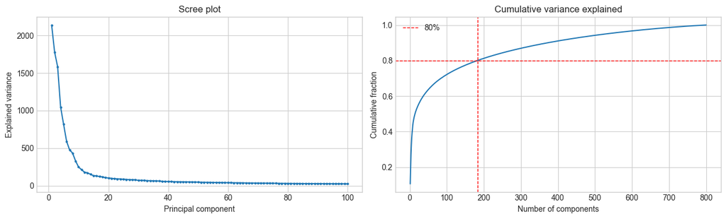

```python
max_components = min(X_std.shape) - 1
components_all, projected_all, explained_all = pca_svd(X_std, k=max_components)

variance_fraction = explained_all / explained_all.sum()
cumulative_fraction = np.cumsum(variance_fraction)
components_for_80 = int(np.searchsorted(cumulative_fraction, 0.80) + 1)

print(f"Computed PCA components: {max_components}")
print(f"Components needed for 80% variance: {components_for_80}")
print(f"Original number of genes: {X_std.shape[1]}")

plot_k = min(100, len(explained_all))
fig, axes = plt.subplots(1, 2, figsize=(13, 4))
axes[0].plot(np.arange(1, plot_k + 1), explained_all[:plot_k], marker="o", markersize=2)
axes[0].set_title("Scree plot")
axes[0].set_xlabel("Principal component")
axes[0].set_ylabel("Explained variance")

axes[1].plot(np.arange(1, len(cumulative_fraction) + 1), cumulative_fraction)
axes[1].axhline(0.80, color="red", linestyle="--", linewidth=1, label="80%")
axes[1].axvline(components_for_80, color="red", linestyle="--", linewidth=1)
axes[1].set_title("Cumulative variance explained")
axes[1].set_xlabel("Number of components")
axes[1].set_ylabel("Cumulative fraction")
axes[1].legend()
plt.tight_layout()
```

The number printed above is far smaller than the original 20,531 genes, showing that the dominant variation in these samples lives in a much lower-dimensional subspace.

## 4(e) 2D PCA visualization

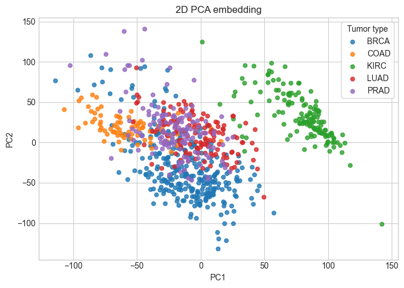

```python
def scatter_embedding(embedding, labels, title, ax=None, xlabel="Dimension 1", ylabel="Dimension 2"):
    if ax is None:
        fig, ax = plt.subplots(figsize=(7, 5))
    classes = sorted(pd.Series(labels).unique())
    cmap = plt.get_cmap("tab10")
    for i, cls in enumerate(classes):
        mask = np.asarray(labels) == cls
        ax.scatter(embedding[mask, 0], embedding[mask, 1], s=24, alpha=0.8, color=cmap(i), label=cls)
    ax.set_title(title)
    ax.set_xlabel(xlabel)
    ax.set_ylabel(ylabel)
    ax.legend(title="Tumor type", frameon=True)
    return ax


pca_2d = projected_all[:, :2]
fig, ax = plt.subplots(figsize=(7, 5))
scatter_embedding(pca_2d, y.to_numpy(), "2D PCA embedding", ax=ax, xlabel="PC1", ylabel="PC2")
plt.tight_layout()
```

PCA should show meaningful tumor-type structure because tissue-specific expression patterns explain a large share of the variance. In a typical run on this dataset, several classes form clear regions, while the two adenocarcinoma classes can be closer or more partially mixed in a purely linear 2D projection.

## 4(f) What do PC1 and PC2 mean?

```python
gene_names = np.asarray(X_df.columns)


def top_loadings(component, gene_names, n=10):
    idx = np.argsort(np.abs(component))[::-1][:n]
    return pd.DataFrame({
        "gene_index": idx,
        "gene": gene_names[idx],
        "loading": component[idx],
        "abs_loading": np.abs(component[idx]),
    })

pc1_top = top_loadings(components_all[0], gene_names, n=10)
pc2_top = top_loadings(components_all[1], gene_names, n=10)

print("Top absolute loadings for PC1:")
display(pc1_top)
print("Top absolute loadings for PC2:")
display(pc2_top)

pc1_genes = set(pc1_top["gene"])
pc2_genes = set(pc2_top["gene"])
print("Overlap among top-10 genes:", sorted(pc1_genes & pc2_genes))
```

```
Top absolute loadings for PC1:
```

|  | gene_index | gene | loading | abs_loading |
| --- | --- | --- | --- | --- |
| 0 | 19862 | gene_19862 | 0.019002 | 0.019002 |
| 1 | 17360 | gene_17360 | 0.018985 | 0.018985 |
| 2 | 13489 | gene_13489 | 0.018966 | 0.018966 |
| 3 | 15158 | gene_15158 | 0.018777 | 0.018777 |
| 4 | 7031 | gene_7031 | 0.018740 | 0.018740 |
| 5 | 7019 | gene_7019 | 0.018657 | 0.018657 |
| 6 | 10788 | gene_10788 | 0.018629 | 0.018629 |
| 7 | 13507 | gene_13507 | -0.018624 | 0.018624 |
| 8 | 6543 | gene_6543 | 0.018595 | 0.018595 |
| 9 | 2288 | gene_2288 | -0.018592 | 0.018592 |

```
Top absolute loadings for PC2:
```

|  | gene_index | gene | loading | abs_loading |
| --- | --- | --- | --- | --- |
| 0 | 3612 | gene_3612 | -0.020273 | 0.020273 |
| 1 | 1222 | gene_1222 | 0.019863 | 0.019863 |
| 2 | 14699 | gene_14699 | -0.019862 | 0.019862 |
| 3 | 1010 | gene_1010 | 0.019829 | 0.019829 |
| 4 | 19498 | gene_19498 | 0.019505 | 0.019505 |
| 5 | 1113 | gene_1113 | -0.019409 | 0.019409 |
| 6 | 3603 | gene_3603 | -0.019346 | 0.019346 |
| 7 | 364 | gene_364 | -0.019225 | 0.019225 |
| 8 | 11153 | gene_11153 | 0.019222 | 0.019222 |
| 9 | 19866 | gene_19866 | 0.019133 | 0.019133 |

```
Overlap among top-10 genes: []
```

The top-loading genes are the genes that drive each principal direction most strongly. PC1 and PC2 usually have different top genes, which means they summarize different expression programs.

## 4(g) UMAP via library

If the next import fails, run this in a notebook cell first:

```
%pip install umap-learn
```

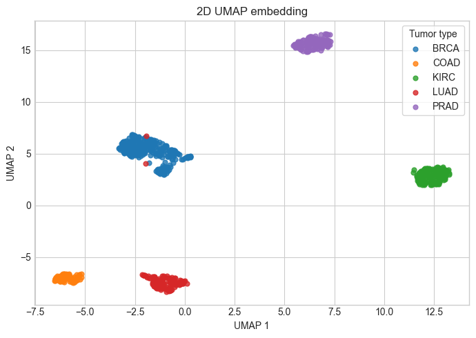

```python
try:
    import umap.umap_ as umap
except ImportError as exc:
    raise ImportError("Install UMAP with `%pip install umap-learn`, then rerun this cell.") from exc

umap_model = umap.UMAP(n_components=2, random_state=RANDOM_STATE)
umap_2d = umap_model.fit_transform(X_std)

fig, ax = plt.subplots(figsize=(7, 5))
scatter_embedding(umap_2d, y.to_numpy(), "2D UMAP embedding", ax=ax, xlabel="UMAP 1", ylabel="UMAP 2")
plt.tight_layout()
```

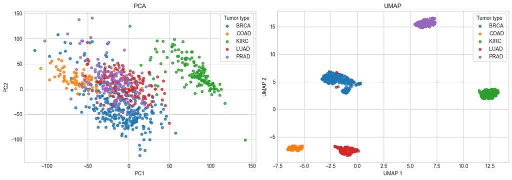

```python
fig, axes = plt.subplots(1, 2, figsize=(14, 5))
scatter_embedding(pca_2d, y.to_numpy(), "PCA", ax=axes[0], xlabel="PC1", ylabel="PC2")
scatter_embedding(umap_2d, y.to_numpy(), "UMAP", ax=axes[1], xlabel="UMAP 1", ylabel="UMAP 2")
plt.tight_layout()
```

UMAP typically gives more visually separated groups than PCA because it can preserve nonlinear local neighborhoods instead of being restricted to one global linear projection. The tradeoff is that UMAP distances and axes are less directly interpretable than PCA loadings.

## 4(h) UMAP hyperparameter exploration

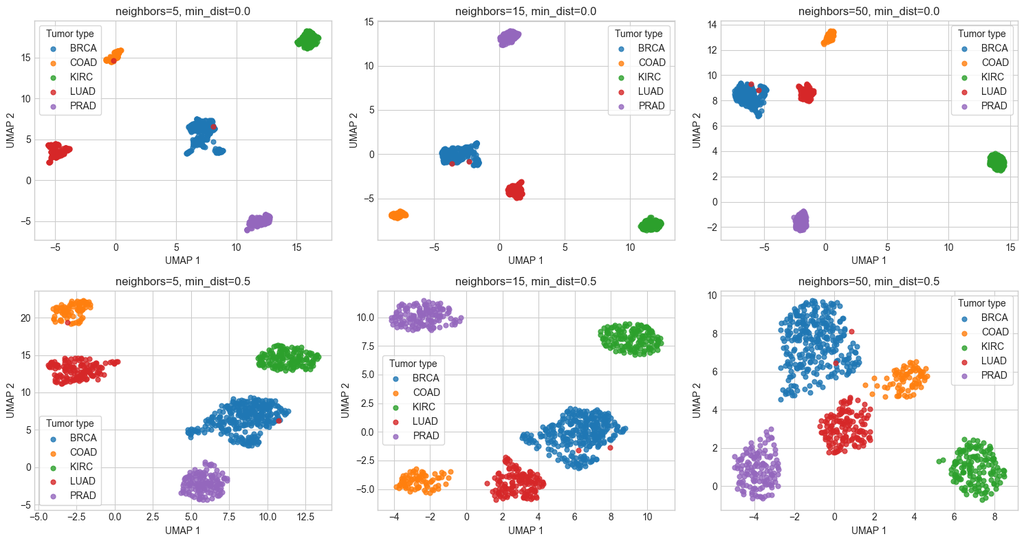

```python
neighbor_values = [5, 15, 50]
min_dist_values = [0.0, 0.5]

fig, axes = plt.subplots(len(min_dist_values), len(neighbor_values), figsize=(15, 8))
umap_grid_embeddings = {}

for row, min_dist in enumerate(min_dist_values):
    for col, n_neighbors in enumerate(neighbor_values):
        reducer = umap.UMAP(
            n_components=2,
            n_neighbors=n_neighbors,
            min_dist=min_dist,
            random_state=RANDOM_STATE,
        )
        emb = reducer.fit_transform(X_std)
        umap_grid_embeddings[(n_neighbors, min_dist)] = emb
        scatter_embedding(
            emb,
            y.to_numpy(),
            f"neighbors={n_neighbors}, min_dist={min_dist}",
            ax=axes[row, col],
            xlabel="UMAP 1",
            ylabel="UMAP 2",
        )

plt.tight_layout()
```

Smaller `n_neighbors` emphasizes very local structure, so clusters usually become tighter and more fragmented. Larger `n_neighbors` preserves more global structure, while larger `min_dist` spreads points out inside each group. For a lab-facing visualization, I would usually ship a middle or larger-neighborhood setting, such as `n_neighbors=15` or `50`, with `min_dist=0.0` if the goal is clean class separation.

## 4(i) Downstream task: does the embedding actually help?

```python
indices = np.arange(len(y))
train_idx, test_idx = train_test_split(
    indices,
    test_size=0.20,
    random_state=RANDOM_STATE,
    stratify=y,
)

X_train_raw = X_df.iloc[train_idx].to_numpy(dtype=np.float64, copy=True)
X_test_raw = X_df.iloc[test_idx].to_numpy(dtype=np.float64, copy=True)
y_train = y.iloc[train_idx].to_numpy()
y_test = y.iloc[test_idx].to_numpy()

train_means = X_train_raw.mean(axis=0)
train_stds = X_train_raw.std(axis=0, ddof=0)
train_stds[train_stds == 0] = 1.0
X_train_full = (X_train_raw - train_means) / train_stds
X_test_full = (X_test_raw - train_means) / train_stds

print("Train size:", X_train_full.shape[0], "Test size:", X_test_full.shape[0])
print("Train class counts:")
display(pd.Series(y_train).value_counts().sort_index())
print("Test class counts:")
display(pd.Series(y_test).value_counts().sort_index())
```

```
Train size: 640 Test size: 161
Train class counts:
```

```
BRCA    240
COAD     62
KIRC    116
LUAD    113
PRAD    109
Name: count, dtype: int64
```

```
Test class counts:
```

```
BRCA    60
COAD    16
KIRC    30
LUAD    28
PRAD    27
Name: count, dtype: int64
```

```python
def fit_logistic_and_score(X_train, X_test, y_train, y_test):
    clf = LogisticRegression(max_iter=2000, random_state=RANDOM_STATE)
    clf.fit(X_train, y_train)
    pred = clf.predict(X_test)
    return accuracy_score(y_test, pred), clf

# Full 20,531-gene baseline.
full_acc, full_clf = fit_logistic_and_score(X_train_full, X_test_full, y_train, y_test)

# PCA embedding fit on training data only, then applied to test data.
# Fit 10 components once so the next cell can also answer the reflection question.
pca_train_components_10, X_train_pca_10d, _ = pca_svd(X_train_full, k=10)
pca_train_center = X_train_full.mean(axis=0)
X_test_pca_10d = (X_test_full - pca_train_center) @ pca_train_components_10.T
X_train_pca_2d = X_train_pca_10d[:, :2]
X_test_pca_2d = X_test_pca_10d[:, :2]
pca_acc, pca_clf = fit_logistic_and_score(X_train_pca_2d, X_test_pca_2d, y_train, y_test)

# UMAP fit on training data only, then transformed for test data.
umap_train_model = umap.UMAP(n_components=2, random_state=RANDOM_STATE)
X_train_umap_2d = umap_train_model.fit_transform(X_train_full)
X_test_umap_2d = umap_train_model.transform(X_test_full)
umap_acc, umap_clf = fit_logistic_and_score(X_train_umap_2d, X_test_umap_2d, y_train, y_test)

accuracy_table = pd.DataFrame({
    "method": ["Full gene expression", "PCA", "UMAP"],
    "dimensions": [X_train_full.shape[1], 2, 2],
    "test_accuracy": [full_acc, pca_acc, umap_acc],
})
display(accuracy_table)
```

|  | method | dimensions | test_accuracy |
| --- | --- | --- | --- |
| 0 | Full gene expression | 20531 | 0.981366 |
| 1 | PCA | 2 | 0.633540 |
| 2 | UMAP | 2 | 0.981366 |

```python
# Optional: check whether 10 PCA components help relative to 2D PCA.
pca10_acc, pca10_clf = fit_logistic_and_score(X_train_pca_10d, X_test_pca_10d, y_train, y_test)
print(f"10D PCA logistic-regression test accuracy: {pca10_acc:.4f}")
```

```
10D PCA logistic-regression test accuracy: 0.9938
```

## 4(j) Summary

```python
summary_table = accuracy_table.copy()
summary_table.loc[len(summary_table)] = ["PCA", 10, pca10_acc]
display(summary_table.sort_values(["dimensions", "method"]))
```

|  | method | dimensions | test_accuracy |
| --- | --- | --- | --- |
| 1 | PCA | 2 | 0.633540 |
| 2 | UMAP | 2 | 0.981366 |
| 3 | PCA | 10 | 0.993789 |
| 0 | Full gene expression | 20531 | 0.981366 |

Recommendation: use UMAP or 2D PCA for exploratory visualization, but use the full standardized expression vector, or a higher-dimensional PCA representation, for downstream prediction. PCA is best when interpretability matters because loadings identify influential genes; UMAP is best when the lab wants a visually clean map of local tumor neighborhoods. I would not treat the 2D plots alone as proof of diagnostic performance, because the classifier accuracy table is the more direct test.